# R Notebook

# Quantium Virtual Internship - Retail Strategy Analysis - Task 2:

## Installing Librarires if not present

```r
install.packages("skimr")
install.packages("ggplot2")
install.packages("tidyverse")
install.packages("data.table")
install.packages("dplyr")
```

## Load required libraries and datasets

```r
library(data.table)
library(ggplot2)
library(tidyr)
library(skimr)
library(dplyr)
```

## Looking at the first few rows of the data

```r
head(QVI_data)
```

```r
str(QVI_data)
```

```r
glimpse(QVI_data)
```

```r
skim_without_charts(QVI_data)
```

## Select control stores

The client has selected store numbers 77, 86 and 88 as trial stores and want control stores to be established stores that are operational for the entire observation period. We would want to match trial stores to control stores that are similar to the trial store prior to the trial period of Feb 2019 in terms of : - Monthly overall sales revenue - Monthly number of customers - Monthly number of transactions per customer

## Adding a new month ID column in the data with the format yyyymm.

```r
QVI_data <- QVI_data %>%
  mutate(month_ID = format(DATE, "%Y%m"))
```

## Filter the dataset for the stores of interest

```r
QVI_data_sub <- QVI_data %>%
  filter(STORE_NBR %in% c(77, 86, 88))
head(QVI_data_sub)
```

## Calculate monthly overall sales revenue

```r
monthly_sales_revenue <- QVI_data_sub %>%
  group_by(STORE_NBR, month_ID) %>%
  summarize(total_sales = sum(TOT_SALES))
head(monthly_sales_revenue)
```

## Calculate monthly number of customers

```r
monthly_customers <- QVI_data_sub %>%
  distinct(STORE_NBR, LYLTY_CARD_NBR, month_ID) %>%
  group_by(STORE_NBR, month_ID) %>%
  summarize(num_customers = n())
```

## Calculate monthly number of transactions per customer

```r
monthly_transactions_per_customer <- QVI_data_sub %>%
  distinct(STORE_NBR, LYLTY_CARD_NBR, month_ID, TXN_ID) %>%
  group_by(STORE_NBR, month_ID) %>%
  summarize(num_transactions = n()) %>%
  left_join(monthly_customers, by = c("STORE_NBR", "month_ID")) %>%
  mutate(transactions_per_customer = num_transactions / num_customers)
```

## We define the measure calculations to use during the analysis.

### Convert data to a data.table object

```r
setDT(QVI_data_sub)
measureOvertime <- QVI_data_sub[, .(totSales  = sum(TOT_SALES),
                                    ## Number of Customers
                                    nCustmoers = uniqueN(LYLTY_CARD_NBR) ,
                                    ## Number of unique or individual customers per Loyalty card
                                    nTxnPerCust = uniqueN(TXN_ID)/ uniqueN(LYLTY_CARD_NBR) ,
                                    ## Number of Chips sold per unique customers
                                    nChipsPerTxn = sum(TOT_SALES)/uniqueN(TXN_ID) ,
                                    ## Average Price Per Unit of Chips
                                    avgPricePerUnit = mean(TOT_SALES / PROD_QTY) )
                                , by = .(STORE_NBR, month_ID)][order(STORE_NBR, month_ID)]
head(measureOvertime) ## displaying the data.table measureOvertime
```

## Filter to the pre-trial period and stores with full observation periods

```r
## Selecting all the stores with values that have 12 rows, i.e. stores that have a full observation period of 12 months. It gives a NUM[] vector.
storesWithFullObs <- unique(measureOvertime[,.N,STORE_NBR])[N == 12, STORE_NBR]
## Filtering the store data to Pre-Trial Period
preTrialMeasures <- measureOvertime[month_ID < 201902 & STORE_NBR %in% storesWithFullObs,]
head(storesWithFullObs)
head(preTrialMeasures)
```

## Create a function to calculate correlation for a measure, looping through each control store.

Now we need to work out a way of ranking how similar each potential control store is to the trial store. We can calculate how correlated the performance of each store is to the trial store. Let’s write a function for this so that we don’t have to calculate this for each trial store and control store pair.

```r
##Let's define inputTable as a metric table with potential comparison stores, metricCol as the store metric used to calculate correlation on, and storeComparison as the store number of the trial store.

calculateCorrelation <- function(inputTable, metricCol, storeComparison){
  # create an empty data table to store the results
  calcCorrTable = data.table(Store1 = numeric(),
                             Store2 = numeric(),
                             corr_measure = numeric())

  storeNumbers <- unique(inputTable[, STORE_NBR])

  for(i in storeNumbers) {

    calculatedMeasure = data.table("Store1" = storeComparison,
                                   "Store2" = i,
                                   "corr_measure" = cor(inputTable[STORE_NBR == storeComparison, eval(metricCol)],
                                                        inputTable[STORE_NBR == i, eval(metricCol)]))

    calcCorrTable <- rbind(calcCorrTable, calculatedMeasure)

  }

  return(calcCorrTable)


}
```

## Making a standardized metric based on the absolute difference between the trial store’s performance and each control store’s performance.

```r
## Create a function to calculate a standardized magnitude distance for a measure,
## looping through each control store

calculateMagnitudeDistance <- function(inputTable,  metricCol, storeComparison){


  calcDistTable = data.table(Store1 = numeric(),
                             Store2 = numeric(),
                             YEARMONTH = numeric(),
                             measure = numeric())

  storeNumbers <- unique(inputTable[, STORE_NBR])

  for(i in storeNumbers) {

    calculatedMeasure = data.table("Store1" = storeComparison,
                                   "Store2" = i,
                                   "YEARMONTH" = inputTable[STORE_NBR == storeComparison, month_ID],
                                   "measure" = abs(inputTable[STORE_NBR == storeComparison, eval(metricCol)] -
                                                     inputTable[STORE_NBR == i, eval(metricCol)]))
    ## Taking the difference of Store Metric i.e, total sales and Number of Customers for both of the trial store and comparing store

    calcDistTable <- rbind(calcDistTable, calculatedMeasure, use.names=FALSE)

  }

  #### Standardize the magnitude distance so that the measure ranges from 0 to 1

  minMaxDist <- calcDistTable[, .(minDist = min(measure),
                                  maxDist = max(measure)),
                              by = c("Store1", "YEARMONTH")]

  distTable <- merge(calcDistTable, minMaxDist, by = c("Store1", "YEARMONTH"))

  ## Normalizing the absolute difference between two Stores of their Store Metric of calculation
  distTable[, magnitudeMeasure := 1 - (measure - minDist)/(maxDist - minDist)]

  ## Creating a new column in a new data table named mag_measure and storing the mean of magnitudeMeasure from the previous table
  finalDistTable <- distTable[, .(mag_measure = mean(magnitudeMeasure)),
                              by = .(Store1, Store2)]

  return(finalDistTable)


}
```

## Using the function created earlier to calculate correlations against store 77 using total sales and number of customers.

We’ll select control stores based on how similar monthly total sales in dollar amounts and monthly number of customers are to the trial stores. So we will need to use our functions to get four scores, two for each of total sales and total customers.

```r
# Function Call
## Using the function created earlier to calculate correlations against store 77 using total sales and number of customers.
trial_store <- 77 # c(77L, 86L, 88L)  we have to use %%in%% for storeComparison

corr_nSales <- calculateCorrelation(preTrialMeasures , quote(totSales), trial_store)
corr_nCustomers <- calculateCorrelation(preTrialMeasures , quote(nCustomers), trial_store)

## Displaying everything

head(corr_nCustomers)

head(corr_nSales)
```

## Calculation of Standardized measure for trial stores

```r
magnitude_nSales <- calculateMagnitudeDistance( preTrialMeasures , quote(totSales), trial_store)
magnitude_nCustomers <- calculateMagnitudeDistance(preTrialMeasures , quote(nCustomers), trial_store)
head(magnitude_nSales)
```

```r
head(magnitude_nCustomers)
```

##Create a combined score composed of correlation and magnitude, by first merging the correlations table with the magnitude table.

Let’s take a simple average of the correlation and magnitude scores for each driver. Note that if we consider it more important for the trend of the drivers to be similar, we can increase the weight of the correlation score (a simple average gives a weight of 0.5 to the corr_weight) or if we consider the absolute size of the drivers to be more important, we can lower the weight of the correlation score.

```r
## merge the correlation and magnitude tables
merged_nSales <- merge(corr_nSales , magnitude_nSales, by = c("Store1", "Store2"))
merged_nCustomers <- merge(corr_nCustomers, magnitude_nCustomers, by = c("Store1", "Store2"))
head(merged_nSales)
head(merged_nCustomers)
```

```r
# calculate the combined score for total sales
corr_weight <- 0.5
mag_weight <- 0.5

# calculate the combined score for total sales with A simple average on the scores would be 0.5 * corr_measure + 0.5 * mag_measure
merged_nSales[ , score_nSales := corr_weight*corr_measure + mag_weight*mag_measure]
head(merged_nSales)
```

```r
# calculate the combined score for number of customers
merged_nCustomers[ , score_nCustomers := corr_weight*corr_measure + mag_weight*mag_measure]
head(merged_nCustomers)
```

## Combine scores across the drivers by first merging our sales scores and customer scores into a single table

Now we have a score for each of total number of sales and number of customers. Let’s combine the two via a simple average.

```r
score_Control <- merge(merged_nSales[, .(Store1, Store2, score_nSales)], merged_nCustomers[, .(Store1, score_nCustomers)], by = "Store1")
score_Control[, finalControlScore := score_nSales * 0.5 + score_nCustomers * 0.5]
head(score_Control)
```

## Selecting the Store with the highest score as it would be the most similar to the trial store.

```r
## Select control store based on the highest matching store (closest to 1 but not exactly 1)
control_store <- score_Control[Store1 == trial_store][order(-finalControlScore)][2, Store2]
paste(control_store)
```

## Visulaizing the similarites between the trial and control stores before the trial period

Now that we have found a control store, let’s check visually if the drivers are indeed similar in the period before the trial.

## Total Sales :

```r
##Visual checks on trends based on the drivers
measureOverTimeSales <- measureOvertime

str(measureOverTimeSales)
## First as we see the month_ID is in chr instead of integer we have to convert it to integer

## Convert the month_ID column from character to integer
measureOverTimeSales[, month_ID := as.integer(month_ID)]

## Check the data type of the month_ID column
str(measureOverTimeSales$month_ID)
```

```r
## Now we measure the past sales
pastSales <- measureOverTimeSales[ , Store_type := ifelse(STORE_NBR == trial_store, "Trial",
                                                          ifelse(STORE_NBR == control_store, "Control", "Other stores"))
                                   ][, totSales := mean(totSales), by = c("month_ID",
                                                                          "Store_type")
                                     ][, TransactionMonth := as.Date(paste(month_ID %/% 100, month_ID %% 100, 1 , sep = "-"), "%Y-%m-%d")
                                       ][month_ID < 201903,]
```

```r
## Displaying the tables created
head(pastSales)
str(pastSales)
```

## Plotting the Trends of Trial , Control and Other Stores according to their respective Total Sales of past Sales

```r
## Now we will plot the trends based on the drivers in past sales
ggplot(pastSales , aes(TransactionMonth,  totSales , color =  Store_type)) + geom_line() + labs(x = "Month of operation", y = "Total sales", title = "Total sales by month")
```

We can see how both of our selected trial and control store have sort of the same trend when we plot them together

## Number Of Customers :

```r
measureOvertimeCusts <- copy(measureOvertime)

## Visual checks on customer count trends by comparing the trial store to the control store and other stores.

pastCustomers <- measureOvertimeCusts[ , Store_type := ifelse(STORE_NBR == trial_store, "Trial",
                                                              ifelse(STORE_NBR == control_store, "Control", "Other stores"))
                                       ][, totSales := mean(totSales), by = c("month_ID",
                                                                              "Store_type")
                                       ][, TransactionMonth := as.Date(paste(month_ID %/% 100, month_ID %% 100, 1 , sep = "-"), "%Y-%m-%d")
                                         ][month_ID < 201903,][order(TransactionMonth), ]
```

```r
## Displaying the tables created
head(pastCustomers)
str(pastCustomers)
```

## Now we will plot the trends based on the drivers in past number of customers

```r
ggplot(pastCustomers , aes(TransactionMonth,  nCustomers , color =  Store_type)) + geom_line() + labs(x = "Month of operation", y = "Number of Customers", title = "Total Number of Customers by month")
ggplot(data = past) +
  geom_line(mapping = aes(x = TransactionMonth , y = nCustomers , color =  Store_type))

summary(pastCustomers[pastCustomers$Store_type == "Other stores", "nCustomers"])
```

## Assessment of trial

The trial period goes from the start of February 2019 to April 2019. We now want to see if there has been an uplift in overall chip sales.

**Scaling the control store’s sales to a level similar to control for any differences between the two stores outside of the trial period.**

```r
## Scale pre-trial control sales to match pre-trial trial store sale

scalingFactorForControlSales <- preTrialMeasures[STORE_NBR == trial_store & month_ID < 201902 , sum(totSales)]/preTrialMeasures[STORE_NBR == control_store & month_ID < 201902 , sum(totSales)]

## Apply the scaling factor

scaledControlSales <- measureOverTimeSales[STORE_NBR == control_store,
                                           ][ , controlSales := totSales * scalingFactorForControlSales]
```

Now that we have comparable sales figures for the control store, we can calculate the percentage difference between the scaled control sales and the trial store’s sales during the trial period.

```r
## Calculating the percentage difference between scaled control sales and trial sales

percentageDiff <- merge( scaledControlSales[, c("month_ID", "controlSales")],
                         measureOvertime[STORE_NBR == trial_store, c("month_ID", "totSales")],
                         by = "month_ID"
                           )[ , percentageDiff := abs(controlSales - totSales)/controlSales]
```

We need to check if the difference is significant enough according to our null hypothesis which is that the trial period is the same as the pre-trial period. We will do that by taking the standard deviation based on the scaled percentage difference in the pre-trial period

```r
## Taking the standard deviation as the first step to check our null hypothesis

stdDev <- sd(percentageDiff[month_ID < 201902 , percentageDiff])

## Note that there are 8 months in the pre-trial period as dof = n - 1, therefore  8 - 1 = 7 degrees of freedom.

degreesOfFreedom <- 7
```

Now, we will test the null hypothesis of there being 0 difference between trial and control stores by calculating the t-values for the trial months and after that we will check the confidence interval which is 95th percentile of the t-distribution with the appropriate degrees of freedom.

```r
## Calculating the t-values for the trial months.
## Note: The test statistic here is (x - u)/standard deviation
## The value 0 in the expression (percentageDiff - 0)/stdDev represents the null hypothesis that there is no difference between the trial and control stores.

percentageDiff[ , tValue := (percentageDiff - 0)/stdDev
                ][ , TransactionMonth := as.Date(paste(month_ID %/% 100,month_ID %% 100, 1,sep = "-"), "%Y-%m-%d")
                     ][month_ID < 201905 & month_ID > 201901, .(TransactionMonth, tValue)]
```

Now we will calculate the 95th percentile of the t-distribution and compare with our t-value.

```r
## Calculating the 95th percentile of the t-distribution with degrees of freedom to compare with our t-value

qt(0.95, df = degreesOfFreedom)
```

We can see that the t-values for March and April is quite large in comparison to the 95th percentile value of the t-distribution. Therefore, we can conclude that the increase in the trial store in March and April is statistically greater than in the control store.

## Visualizing the Results from our previous comparisons by :

Plotting the sales of control store , sales of the trial stores and the 95th percentile value of sales of the control store.

```r
## Visualizing the sales of control store , sales of the trial stores and the 95th percentile value of sales of the control store.
pastSales <- measureOverTimeSales[, totSales := mean(totSales), by = c("month_ID", "Store_type")
                                    ][Store_type %in% c("Trial", "Control")]
```

```r
## Control store 95th percentile
pastSales_Conrtols95 <- pastSales[Store_type == "Control",
                                  ][, totSales := totSales * (1 + stdDev * 2)
                                    ][, Store_type := "Conrol 95th % confidence interval"]
head(pastSales_Conrtols95)
```

```r
## Control store 5th percentile
pastSales_Controls5 <- pastSales[Store_type == "Control",
                                 ][, totSales := totSales * (1 - stdDev * 2)
                                   ][, Store_type := "Control 5th % confidence interval"]
head(pastSales_Controls5)
```

```r
## Combining everything
trialAssessment <- rbind(pastSales, pastSales_Conrtols95, pastSales_Controls5)
head(trialAssessment)
```

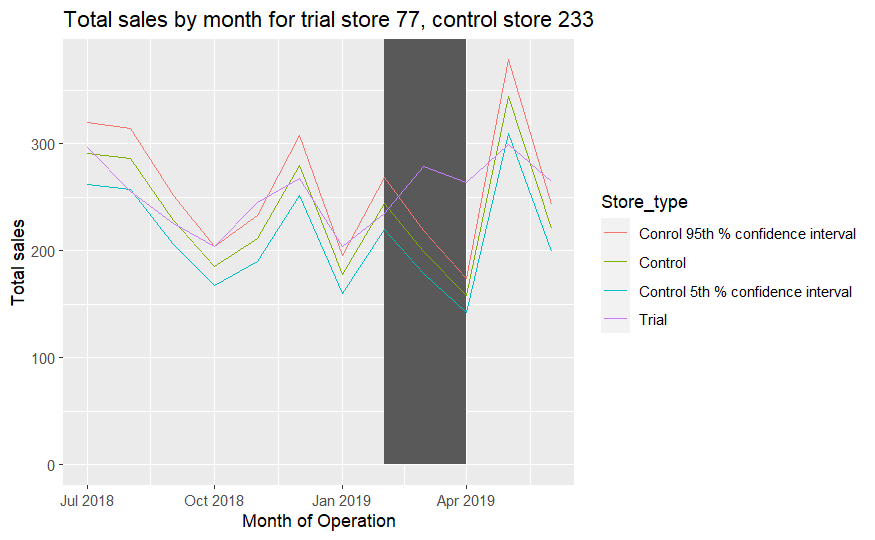

```r
## Plotting everything in one graph

ggplot(data = trialAssessment ,mapping = aes(x = TransactionMonth , y = totSales , color = Store_type) ) +
  geom_rect(data = trialAssessment[month_ID < 201905 & month_ID > 201901 ,],
            mapping = aes(xmin = min(TransactionMonth), xmax = max(TransactionMonth), ymin = 0 , ymax = Inf, color  = NULL), show.legend = FALSE) +
  geom_line() +
  labs(x = "Month of Operation", y = "Total sales" ,title =  "Total sales by month for trial store 77, control store 233")
```

```r
NA
NA
```

## Scaling for Number of Customers

```r
scaledControlCustomers <- measureOvertimeCusts[STORE_NBR == control_store,
                                               ][, controlCustomers := nCustomers * scalingFactoForControlCust]

#### Calculate the percentage difference between scaled control sales and trial sales
percentageDiffCust <- merge(scaledControlCustomers[, c("month_ID", "controlCustomers")],
                            measureOvertimeCusts[STORE_NBR == trial_store, c("nCustomers", "month_ID")],
                            by = "month_ID")[, percentageDiff := abs(controlCustomers - nCustomers)/ controlCustomers]
```

## Let’s again see if the difference is significant visually for Trial Store 77 for number of customers

As our null hypothesis is that the trial period is the same as the pre-trial period, let’s take the standard deviation based on the scaled percentage difference in the pre-trial period.

```r
## Taking Standard Deviation and initializing degrees of freedom
stdDev2 <- sd(percentageDiffCust[month_ID < 201902, percentageDiff])

degreesOfFreedom <- 7
```

```r
## Trial and control store number of customers
pastCustomers <- measureOvertimeCusts[, nCusts := mean(nCustomers),
                                      by = c("month_ID", "Store_type")
                                      ][Store_type %in% c("Trial", "Control")]

## Control store 95th percentile
pastCustomers_Controls95 <- pastCustomers[Store_type == "Control",
                                          ][, nCusts := nCusts * (1 + stdDev2*2)][, Store_type := "Control 95th % CI"]


## Control store 5th percentile
pastCustomers_Controls5 <- pastCustomers[Store_type == "Control",
                                         ][, nCusts := nCusts * (1 - stdDev2*2)][, Store_type := "Control 5th % CI"]

trialAssessmentCust <- rbind(pastCustomers, pastCustomers_Controls95, pastCustomers_Controls5)
```

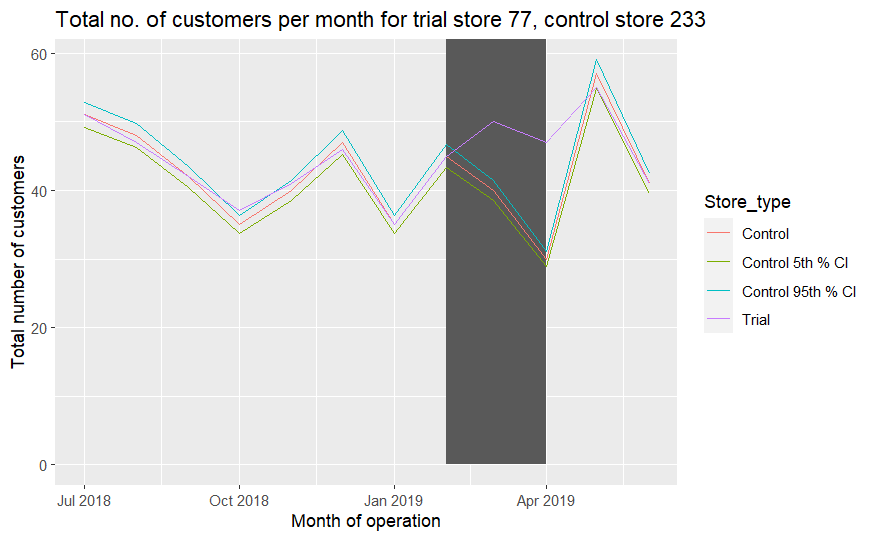

```r
## Plotting these in one nice graph
ggplot(trialAssessmentCust, aes(x = TransactionMonth, y = nCusts, color = Store_type)) +
  geom_rect(data = trialAssessmentCust[month_ID < 201905 & month_ID > 201901, ],
            aes(xmin = min(TransactionMonth), xmax = max(TransactionMonth),
                ymin = 0, ymax = Inf, color = NULL), show.legend = FALSE) +
  geom_line() + labs(x = "Month of operation", y = "Total number of customers",
                     title = "Total no. of customers per month for trial store 77, control store 233")
```

## For Trial Store : 86

We are going to go through the same process of calculating the Correlation and Normalization using our two previously initialized functions i.e, calculateCorrelation and calculateMagnitudeDistance. We need to use the functions for two metrics which are total sales and number of customers. So we will have 4 variables from 2 functions using 2 Metrics for comparison. We will do the same for trial store 88 later.

```r
trial_store86 <- 86

## Calculating the correlations of total sales and number of customers
corr_nSales86 <- calculateCorrelation( preTrialMeasures, quote(totSales), trial_store86)
corr_nCustomers86 <- calculateCorrelation( preTrialMeasures, quote(nCustomers), trial_store86)

## Calculating the Normalized measure of total sales and number of customers
magnitude_nSales86 <- calculateMagnitudeDistance( preTrialMeasures, quote(totSales), trial_store86)
magnitude_nCustomer86 <- calculateMagnitudeDistance( preTrialMeasures, quote(nCustomers), trial_store86)
```

## Creating a score based on the both correlation and normalization by taking a simple average

```r
## For Sales

score_nSales86 <- merge(corr_nSales86,
                        magnitude_nCustomer86,
                        by = c("Store1", "Store2"))[, scoreNSales := (corr_measure * corr_weight) +
                                                      (mag_measure * mag_weight)]


## For Number of Customers

score_nCustomer86 <- merge(corr_nCustomers86, magnitude_nCustomer86,
                           by = c("Store1", "Store2"))[, scoreNCust := (corr_measure * corr_weight) +
                                                         (mag_measure * mag_weight)]


## Combining the scores across all the drivers
score_Control86 <- merge(score_nSales86,
                         score_nCustomer86,
                         by = c("Store1", "Store2"))[, finalControlScore := scoreNSales * 0.5 + scoreNCust * 0.5]
```

## Selecting the Control Store for trial store 86

```r
## Selecting the control store for Trial store 86 by selecting the highest score but not the trial store itself

control_store86 <- score_Control86[Store1 == trial_store86, ][order(-finalControlScore)][2, Store2]

control_store86
```

## Visualizing the trends of Trial, Control & Other Stores for Trial Store 86

We are going to plot the trends of Trial , Control & Other stores according with the two previously calculated metrics total sales and number of customers to find how similar they are.

```r
measureOverTimeSales86 <- copy(measureOvertime)

## For past Sales
pastSales86 <- measureOverTimeSales86[, Store_type := ifelse(STORE_NBR == trial_store86, "Trial",
                                                           ifelse(STORE_NBR == control_store86, "Control", "Other stores"))
                                    ][, totSales := mean(totSales),by = c("month_ID", "Store_type")
                                      ][, TransactionMonth := as.Date(paste(month_ID %/% 100, month_ID %% 100, 1, sep = "-"),"%Y-%m-%d")
                                        ][month_ID < 201903, ]

## Plotting the Sales trending
ggplot(pastSales86, aes(TransactionMonth, totSales, color = Store_type)) +
  geom_line(aes(linetype = Store_type)) +
  labs(x = "Months", y = "Total sales",
       title = "Average total sales by month for trial store 86 and control store 155 for pre-trial period")
```

```r
## For Number of Customers

measureOverTimeCusts86 <- copy(measureOvertime)

## For Number Customers
pastCustomers86 <- measureOverTimeCusts86[, Store_type := ifelse(STORE_NBR == trial_store86, "Trial",
                                                               ifelse(STORE_NBR == control_store86, "Control", "Other stores"))
                                          ][, numberCustomers := mean(nCustomers), by = c("month_ID", "Store_type")
                                            ][, TransactionMonth := as.Date(paste(month_ID %/% 100, month_ID %% 100, 1, sep = "-"),"%Y-%m-%d")
                                              ][month_ID < 201903, ]

## Plotting
ggplot(pastCustomers86, aes(TransactionMonth, numberCustomers, color = Store_type)) +
  geom_line(aes(linetype = Store_type)) +
  labs(x = "Month of Operation", y = "Number of customers", title = "Average number of customers by month for trail store 86 and control store 155 for the pre_trial preiod")
```

As we can observe that the trends of the trail and control stores are generally the same for the pre-trial period.

## Trial Assessment for Trial Store 86:

We will now move forward with assessment of trial like previously done with trial store 77.

## Scaling the control stores to match the trial stores for the pre-trail period

```r
## Scaling the control stores

scalingFactorForControlSales86 <- preTrialMeasures[STORE_NBR == trial_store86 &
                                                     month_ID < 201902,
                                                   sum(totSales)
                                                  ]/preTrialMeasures[STORE_NBR == control_store86 & month_ID < 201902, sum(totSales)]

## Applying our scaling factor on control store sales

scaledControlSales86 <- measureOverTimeSales86[STORE_NBR == control_store86,
                                             ][, controlSales := totSales * scalingFactorForControlSales86]
```

After scaling we are going to find out the percentage difference of the total sales of control and trial stores

```r
## Calculate the percentage difference between scaled control store sales and trial store sales
percentageDiff86 <- merge(scaledControlSales86[, c("month_ID", "controlSales")],
                          measureOvertime[STORE_NBR == trial_store86, c("month_ID", "totSales")],
                          by = "month_ID")[, percentageDiff := abs(controlSales - totSales)/controlSales]
```

We have our Null hypotheses as the trial period sales being same as the pre-trial period sales, which we are going to test by first calculating the t-values and then compare with the 95% confidence level of the t-distribution.

```r
## Taking the standard deviation

stdDevSales86 <- sd(percentageDiff86[ month_ID < 201902, percentageDiff])

## Getting all the past sales of Trial and Control Store
pastSales86 <- measureOverTimeSales86[, totSales := mean(totSales), by = c("month_ID", "Store_type")
                                        ][Store_type %in% c("Trial", "Control"), ]

## Control store 95th percentile
pastSales86_Controls95 <- pastSales86[Store_type == "Control",
                                      ][, totSales := totSales * (1 + stdDevSales86 * 2)
                                        ][, Store_type := "Control Store 95% confidence interval"]

## Control store 5th percentile
pastSales86_Controls5 <- pastSales86[Store_type == "Control",
                                     ][, totSales := totSales * (1 - stdDevSales86 * 2)
                                       ][, Store_type := "Control 5% confidence interval"]

## Binding together of pastSales86, Controls95, Controls5 together
trialAssessmentSales86 <- rbind(pastSales86, pastSales86_Controls5, pastSales86_Controls95)
```

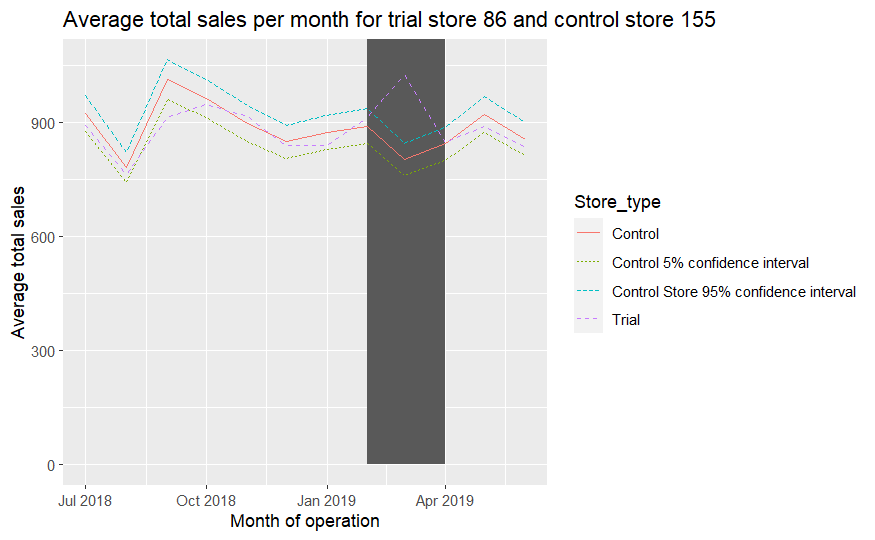

```r
## Plot these all in one graph
ggplot(trialAssessmentSales86, aes(TransactionMonth, totSales, color = Store_type)) +
  geom_rect(data = trialAssessmentSales86[ month_ID < 201905 & month_ID > 201901, ],
            aes(xmin = min(TransactionMonth), xmax = max(TransactionMonth),
                ymin = 0, ymax = Inf, color = NULL), show.legend = FALSE) +
  geom_line(aes(linetype = Store_type)) +
  labs(x = "Month of operation", y = "Average total sales", title = "Average total sales per month for trial store 86 and control store 155")
```

```r
NA
NA
```

Now we are going to look at the trends for the number of customers for the trial store of 86 and compare it with it’s control store which is 155.

```r
## Scaling pre-trial control store for number of customer to match pre-trial trial store.

scalingFactorForControlCust86 <- preTrialMeasures[STORE_NBR == trial_store86 &
                                                    month_ID < 201902,
                                                  sum(nCustomers)
                                                  ]/preTrialMeasures[STORE_NBR == control_store86 & month_ID < 201902, sum(nCustomers)]


## Applying scaling factor to the control stores for number of customers

scaledControlCustomers86 <- measureOverTimeCusts86[STORE_NBR == control_store86,
                                                 ][, controlCustomers := nCustomers * scalingFactorForControlCust86]
```

```r
## Calculate the percentage difference
percentageDiffCust86 <- merge(scaledControlCustomers86[, c("month_ID", "controlCustomers")],
                              measureOvertime[STORE_NBR == trial_store86, c("month_ID", "nCustomers")],
                              by = "month_ID")[, percentageDiff := abs(controlCustomers - nCustomers) / controlCustomers]
```

But first as our Null hypotheses states that the trial period sales being same as the pre-trial period sales, which we are going to test by first calculating the t-values and then compare with the 95% confidence level of the t-distribution.

```r
## Taking the standard deviation

stdDevCust86 <- sd(percentageDiffCust86[month_ID < 201902, percentageDiff])

## Trial and control store number of customers
pastCustomers86 <- measureOverTimeCusts86[, nCusts := mean(nCustomers), by = c("month_ID", "Store_type")
                                        ][Store_type %in% c("Trial", "Control"), ]
```

```r
## Control 95th percentile
pastCustomers86_Controls95 <- pastCustomers86[Store_type == "Control",
                                              ][, nCusts := nCusts * (1 + (stdDevCust86 * 2))
                                                ][, Store_type := "Control Store 95% confidence interval"]

## Control 5th percentile
pastCustomers86_Controls5 <- pastCustomers86[Store_type == "Control",
                                             ][, nCusts := nCusts * (1 - (stdDevCust86 * 2))
                                               ][, Store_type := "Control Store 5% confidence interval"]

## Row bind pastCustomers86, pastCustomers86_Controls95, pastCustomers86_Controls5
trialAssessmentCust86 <- rbind(pastCustomers86, pastCustomers86_Controls5, pastCustomers86_Controls95)
```

## Visualizing the trends of number of customers for trial store 86, control store 155 and other stores

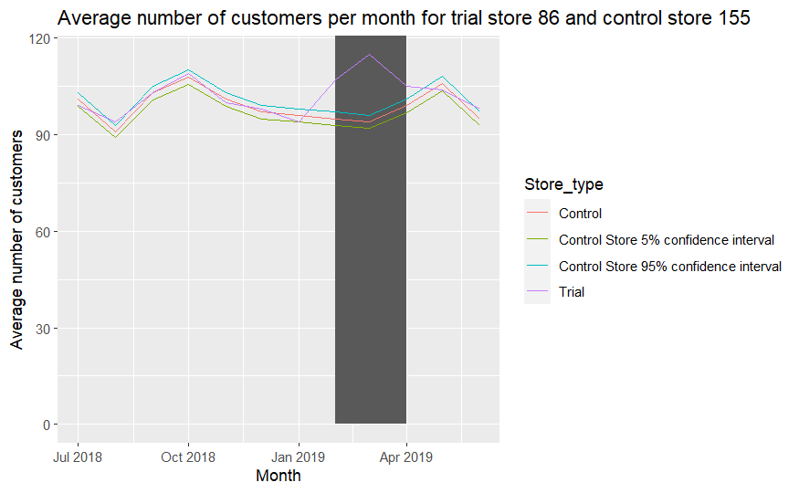

```r
## Plotting the trends of number of customers for the trial period
ggplot(trialAssessmentCust86, aes(TransactionMonth, nCusts, color = Store_type)) +
  geom_rect(data = trialAssessmentCust86[month_ID < 201905 & month_ID > 201901, ],
            aes(xmin = min(TransactionMonth), xmax = max(TransactionMonth),
                ymin = 0, ymax = Inf, color = NULL), show.legend = FALSE) +
  geom_line() +
  labs(x = "Month", y = "Average number of customers", title = "Average number of customers per month for trial store 86 and control store 155")
```

Let’s do the same calculations for our last trial store which is 88.

## Trial store 88 :

First we will use our previous two functions to calculate the correlation and normalized data for both of our metrics i.e , total sales and number of customers.

```r
trial_store88 <- 88

## Calculating the correlations of total sales and number of customers
corr_nSales88 <- calculateCorrelation(preTrialMeasures, quote(totSales), trial_store88)
corr_nCustomers88 <- calculateCorrelation(preTrialMeasures, quote(nCustomers), trial_store88)

## Calculating the Normalized measure of total sales and number of customers
magnitude_nSales88 <- calculateMagnitudeDistance(preTrialMeasures, quote(totSales), trial_store88)
magnitude_nCustomers88 <- calculateMagnitudeDistance(preTrialMeasures, quote(nCustomers), trial_store88)
```

## Creating a score based on the both correlation and normalization by taking a simple average

```r
## For Sales
score_NSales88 <- merge(corr_nSales88, magnitude_nSales88,
                        by = c("Store1", "Store2")
                        )[, scoreNSales := (corr_measure*corr_weight) +(mag_measure * mag_weight)]


## For Number of Customers
score_NCustomers88 <- merge(corr_nCustomers88, magnitude_nCustomers88,
                            by = c("Store1", "Store2")
                            )[, scoreNCust :=(corr_measure * corr_weight) + (mag_measure * mag_weight)]

## Combining the scores across all the drivers
score_Control88 <- merge(score_NSales88, score_NCustomers88, by = c("Store1", "Store2")
                         )[, finalControlScore := (scoreNSales * 0.5) + (scoreNCust * 0.5)]
```

```r
## Selecting the control store for Trial store 86 by selecting the highest score but not the trial store itself
control_store88 <- score_Control88[order(-finalControlScore)][2, Store2]

control_store88
```

## Visualizing the trends of Trial, Control & Other Stores for Trial Store 88

Plotting the trends of Trial , Control & Other stores according with the two previously calculated metrics total sales and number of customers to find how similar they are.

```r
measureOverTimeSales88 <- copy(measureOvertime)

## For past Sales
pastSales88 <- measureOverTimeSales88[, Store_type := ifelse(STORE_NBR == trial_store88, "Trial",
                                                             ifelse(STORE_NBR == control_store88, "Control", "Other stores"))
                                      ][, totSales := mean(totSales),by = c("month_ID", "Store_type")
                                        ][, TransactionMonth := as.Date(paste(month_ID %/% 100, month_ID %% 100, 1, sep = "-"),"%Y-%m-%d")
                                          ][month_ID < 201903, ]

## Plotting the Sales trending
ggplot(pastSales88, aes(TransactionMonth, totSales, color = Store_type)) +
  geom_line(aes(linetype = Store_type)) +
  labs(x = "Months", y = "Total sales",
       title = "Average total sales by month for trial store 88 and control store 237 for pre-trial period")
```

The trial and control stores have similar total sales. Next, number of customers.

```r
## For Number of Customers

measureOverTimeCusts88 <- copy(measureOvertime)

## For Number Customers
pastCustomers88 <- measureOverTimeCusts88[, Store_type := ifelse(STORE_NBR == trial_store88, "Trial",
                                                                 ifelse(STORE_NBR == control_store88, "Control", "Other stores"))
                                          ][, numberCustomers := mean(nCustomers), by = c("month_ID", "Store_type")
                                            ][, TransactionMonth := as.Date(paste(month_ID %/% 100, month_ID %% 100, 1, sep = "-"),"%Y-%m-%d")
                                              ][month_ID < 201903, ]

## Plotting
ggplot(pastCustomers88, aes(TransactionMonth, numberCustomers, color = Store_type)) +
  geom_line(aes(linetype = Store_type)) +
  labs(x = "Month of Operation", y = "Number of customers", title = "Average number of customers by month for trail store 88 and control store 297 for pre_trial preiod")
```

## Trial Assessment for trial store 88 :

We will now move forward with assessment of trial store 88 and compare it’s metrics of total sales and number of customers

```r
## Scaling the control stores

scalingFactorForControlSales88 <- preTrialMeasures[STORE_NBR == trial_store88 &
                                                     month_ID < 201902,
                                                   sum(totSales)
                                                   ]/preTrialMeasures[STORE_NBR == control_store88 & month_ID < 201902, sum(totSales)]

## Applying our scaling factor on control store sales

scaledControlSales88 <- measureOverTimeSales88[STORE_NBR == control_store88,
                                               ][, controlSales := totSales * scalingFactorForControlSales88]
```

After scaling we are going to find out the percentage difference of the total sales of control and trial stores

```r
## Calculate the percentage difference between scaled control store sales and trial store sales
percentageDiff88 <- merge(scaledControlSales88[, c("month_ID", "controlSales")],
                          measureOvertime[STORE_NBR == trial_store88, c("month_ID", "totSales")],
                          by = "month_ID")[, percentageDiff := abs(controlSales - totSales)/controlSales]
```

But first as our Null hypotheses states that the trial period sales being same as the pre-trial period sales, which we are going to test by first calculating the t-values and then compare with the 95% confidence level of the t-distribution.

```r
## Taking the standard deviation
stdDevSales88 <- sd(percentageDiff88[ month_ID < 201902, percentageDiff])

## Getting all the past sales of Trial and Control Store
pastSales88 <- measureOverTimeSales88[, totSales := mean(totSales), by = c("month_ID", "Store_type")
                                      ][Store_type %in% c("Trial", "Control"), ]

## Control store 95th percentile
pastSales88_Controls95 <- pastSales88[Store_type == "Control",
                                      ][, totSales := totSales * (1 + stdDevSales88 * 2)
                                        ][, Store_type := "Control Store 95% confidence interval"]

## Control store 5th percentile
pastSales88_Controls5 <- pastSales88[Store_type == "Control",
                                     ][, totSales := totSales * (1 - stdDevSales88 * 2)
                                       ][, Store_type := "Control 5% confidence interval"]

## Binding together of pastSales88, Controls95, Controls5 together
trialAssessmentSales88 <- rbind(pastSales88, pastSales88_Controls5, pastSales88_Controls95)
```

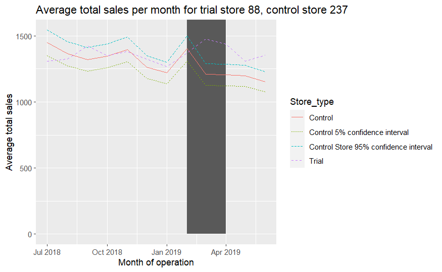

```r
## Plot these all in one graph
ggplot(trialAssessmentSales88, aes(TransactionMonth, totSales, color = Store_type)) +
  geom_rect(data = trialAssessmentSales88[ month_ID < 201905 & month_ID > 201901, ],
            aes(xmin = min(TransactionMonth), xmax = max(TransactionMonth),
                ymin = 0, ymax = Inf, color = NULL), show.legend = FALSE) +
  geom_line(aes(linetype = Store_type)) +
  labs(x = "Month of operation", y = "Average total sales", title = "Average total sales per month for trial store 88, control store 237")
```

The results show that the trial in store 88 is significantly different to its control store in the trial period as the trial store performance lies outside of the 5% and 95% confidence interval of the control store in 2 out of the 3 trial months.

Now we are going to look at the trends for the number of customers for the trial store of 88 and compare it with it’s control store which is 237.

```r
## Scaling pre-trial control store for number of customer to match pre-trial trial store.

scalingFactorForControlCust88 <- preTrialMeasures[STORE_NBR == trial_store88 &
                                                    month_ID < 201902,
                                                  sum(nCustomers)
                                                  ]/preTrialMeasures[STORE_NBR == control_store88 & month_ID < 201902, sum(nCustomers)]


## Applying scaling factor to the control stores for number of customers

scaledControlCustomers88 <- measureOverTimeCusts88[STORE_NBR == control_store88,
                                                   ][, controlCustomers := nCustomers * scalingFactorForControlCust88]
```

```r
## Calculate the percentage difference
percentageDiffCust88 <- merge(scaledControlCustomers88[, c("month_ID", "controlCustomers")],
                              measureOvertime[STORE_NBR == trial_store88, c("month_ID", "nCustomers")],
                              by = "month_ID")[, percentageDiff := abs(controlCustomers - nCustomers) / controlCustomers]
```

But first as our Null hypotheses states that the trial period sales being same as the pre-trial period sales, which we are going to test by first calculating the t-values and then compare with the 95% confidence level of the t-distribution.

```r
## Taking the standard deviation
stdDevCust88 <- sd(percentageDiffCust88[month_ID < 201902, percentageDiff])



## Trial and control store number of customers
pastCustomers88 <- measureOverTimeCusts88[, nCusts := mean(nCustomers), by = c("month_ID", "Store_type")
                                          ][Store_type %in% c("Trial", "Control"), ]



## Control 95th percentile
pastCustomers88_Controls95 <- pastCustomers88[Store_type == "Control",
                                              ][, nCusts := nCusts * (1 + (stdDevCust88 * 2))
                                                ][, Store_type := "Control Store 95% confidence interval"]

## Control 5th percentile
pastCustomers88_Controls5 <- pastCustomers88[Store_type == "Control",
                                             ][, nCusts := nCusts * (1 - (stdDevCust88 * 2))
                                               ][, Store_type := "Control Store 5% confidence interval"]

## Row bind pastCustomers88, pastCustomers88_Controls95, pastCustomers88_Controls5
trialAssessmentCust88 <- rbind(pastCustomers88, pastCustomers88_Controls5, pastCustomers88_Controls95)
```

## Visualizing the trends of number of customers for trial store 88, control store 237 and other stores

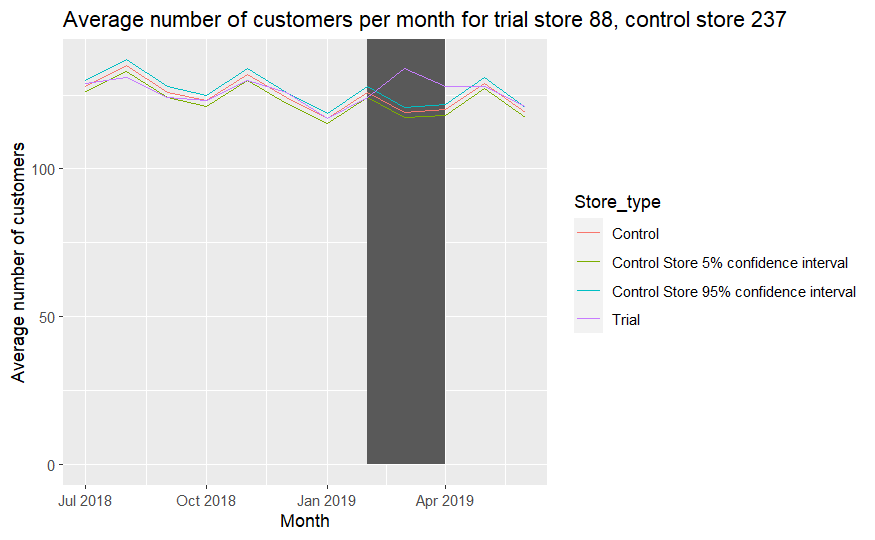

```r
## Plotting the trends of number of customers for the trial period
ggplot(trialAssessmentCust88, aes(TransactionMonth, nCusts, color = Store_type)) +
  geom_rect(data = trialAssessmentCust88[month_ID < 201905 & month_ID > 201901, ],
            aes(xmin = min(TransactionMonth), xmax = max(TransactionMonth),
                ymin = 0, ymax = Inf, color = NULL), show.legend = FALSE) +
  geom_line() +
  labs(x = "Month", y = "Average number of customers", title = "Average number of customers per month for trial store 88, control store 237 ")
```

```r
NA
NA
```

Total number of customers in the trial period for the trial store is significantly high than the control store, for 2 out of 3 months. This indicates a positive trial effect.

**Conclusion :**

We’ve found control stores 233, 155, 237 for trial stores 77, 86 and 88 respectively. The results for trial stores 77 and 88 during the trial period show a significant difference in at least two of the three trial months but this is not the case for trial store 86. We can check with the client if the implementation of the trial was different in trial store 86 but overall, the trial shows a significant increase in sales.